# Bio-Sparte

### Libraries

Library aufrufen das wir nutzen wollen

### Connection

Datanbankverbindung aufbauen

### Grabbing the data

Abrufen von daten um damit umzugehen

#### Control missing data (NA)

Kontrolle ob es fehlende werte gibt in der tabelle t_aisles

##### Aisle

```
## [1] 0
```

```
## [1] 0
```

##### Departments

```
## [1] 0
```

```
## [1] 0
```

##### Orders

```
## [1] 0
```

```
## [1] 0
```

```
## [1] 0
```

```
## [1] 0
```

```
## [1] 0
```

```
## [1] 0
```

###### Kunden die zum ersten mal einkaufen

Es fehlen 206209 werte von 3421083 für days_since_prior (6.0275942%.

Es könnten first-time Kunden sein, also die Kunden die ihre erste Bestellung machen

##### Products

```
## [1] 0
```

```
## [1] 0
```

Jetzt wollen wir graphisch das verhältnis von Bio- zu nicht Bio-Produkte aufzeichnen

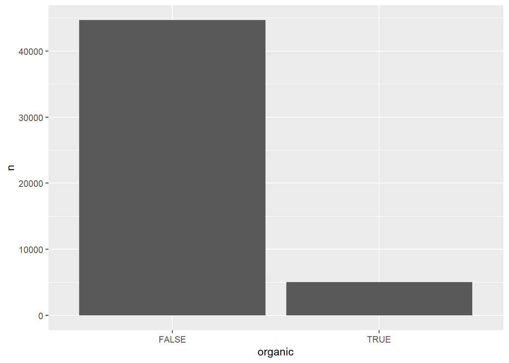

```r
Verhalt_Bio_bought <- t_products
```

### Verhältnis Bio/Nicht-bio in departments & aisles

Wir möchten auch Visualizieren was die Verhältnisse sind, zwischen die Offerte an Bio-produkte in den verschiedene Departments und Aisles.

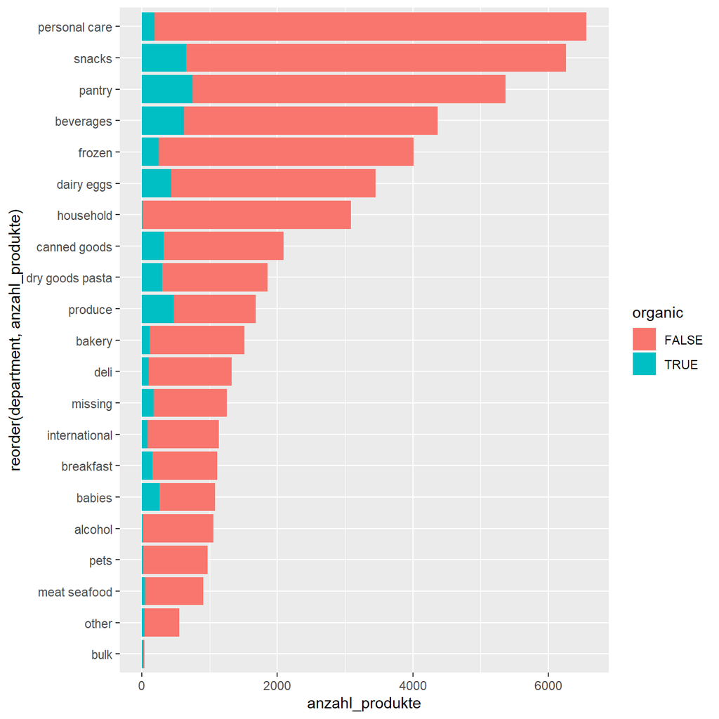

Man kann sehen das die Anzahl an Bio-Produkte in den Departments sehr swach ist, im gegensatz zu den “normalen” Produkten.

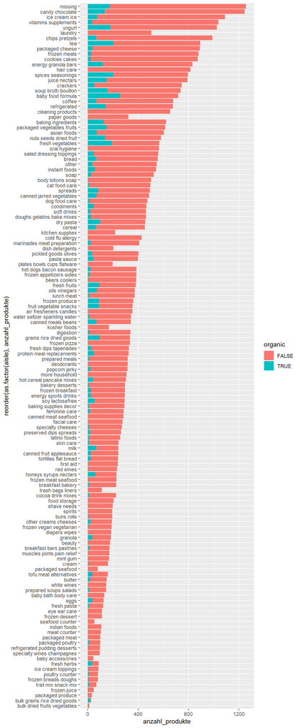

Man kann auch hier sehen das der Verhältniss zwischen Bio-Produkten und nicht Bio_Produkten niedrig ist in spezifische aisles. Es gibt sogar aisles wo es keinlerei Bio-Produkten gibt. Dafür aber gibt es andere aisles wo der Verhältnis viel grösser ist, z.b. Baby Food Formulas und Fresh Vegetables.

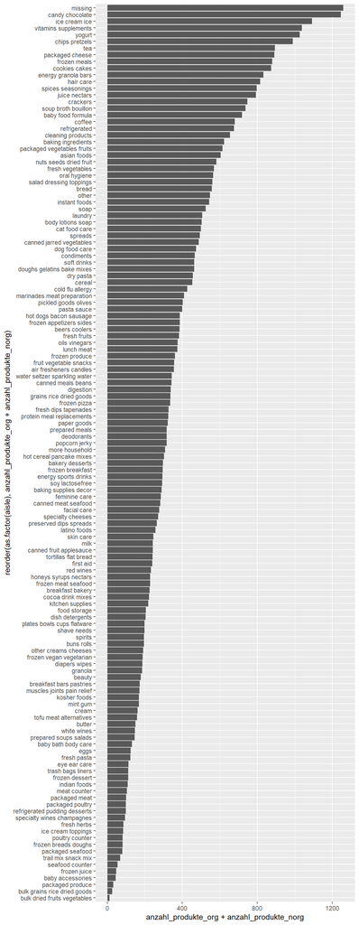

### Determine most bought products

Wir möchten wissen welche Produkte am meisten eingekauft werden und ob diese Organic oder nicht sind

| organic | product_name | n |
| --- | --- | --- |
| FALSE | Banana | 18726 |
| TRUE | Bag of Organic Bananas | 15480 |
| TRUE | Organic Strawberries | 10894 |
| TRUE | Organic Baby Spinach | 9784 |
| FALSE | Large Lemon | 8135 |
| TRUE | Organic Avocado | 7409 |
| TRUE | Organic Hass Avocado | 7293 |
| FALSE | Strawberries | 6494 |
| FALSE | Limes | 6033 |
| TRUE | Organic Raspberries | 5546 |

[output cut: 20 more lines]

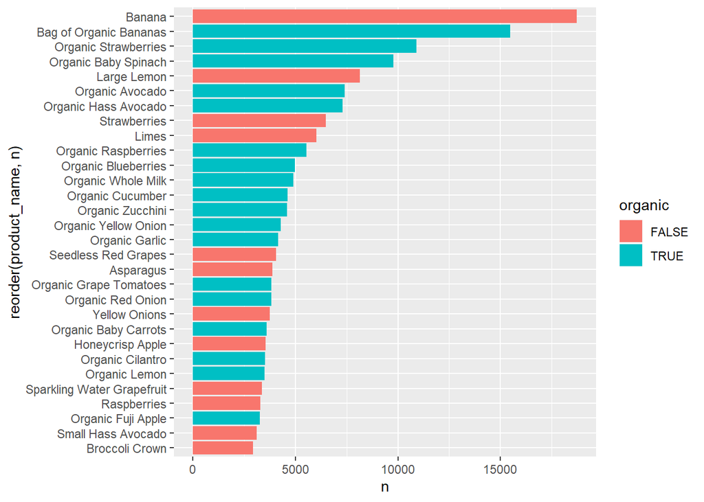

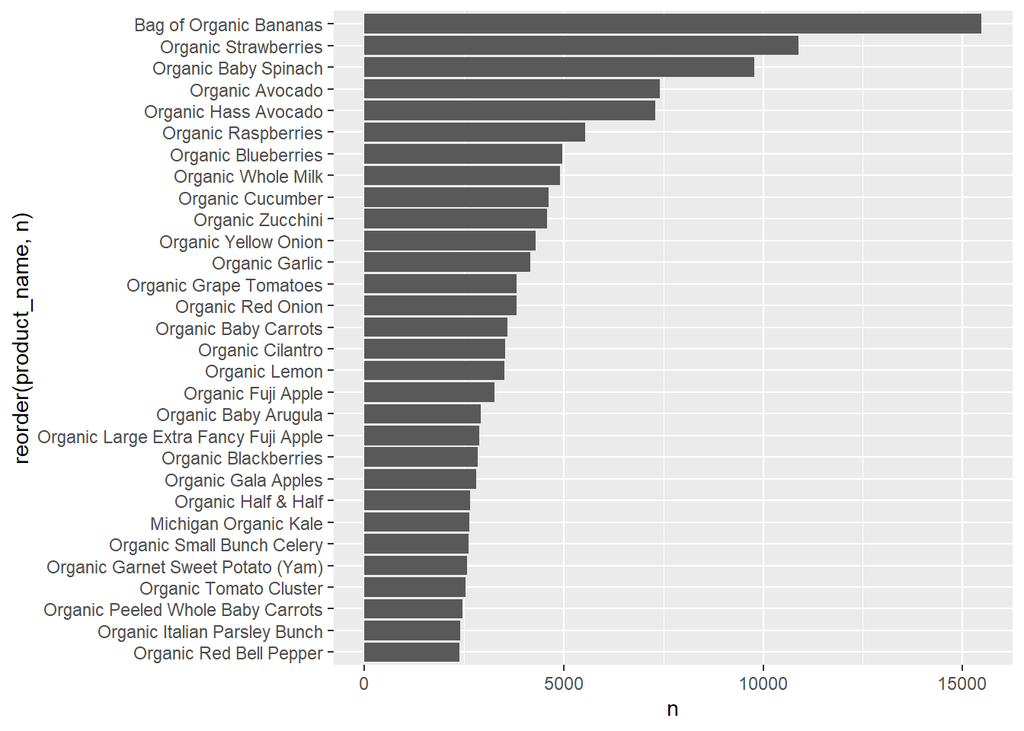

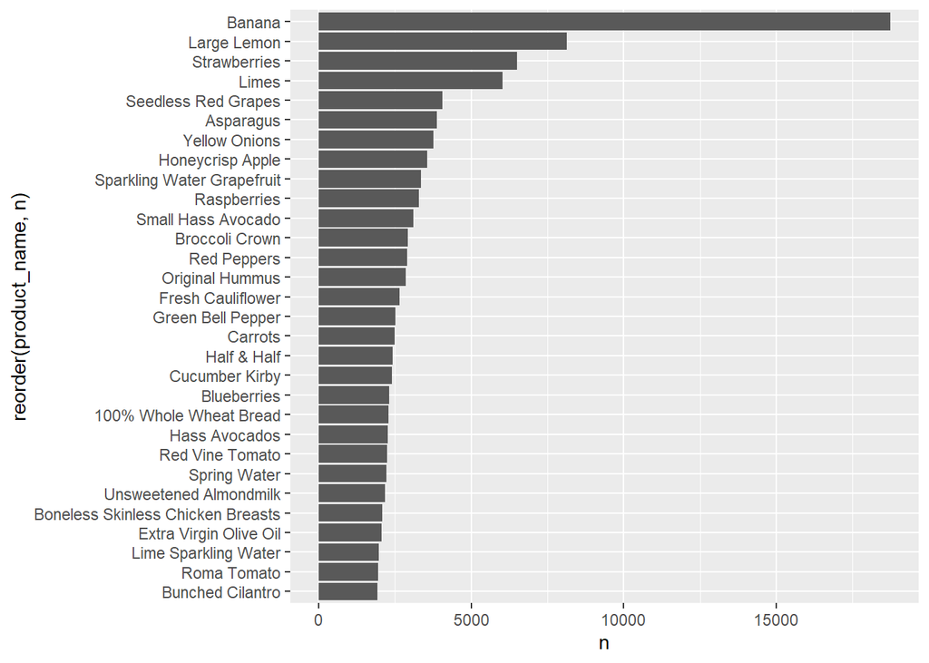

## Stammkunden analyse

Ein ziele wäre die Stammkunden erkennen und sehen ob sie verschieden einkaufen, z.b eine höhere Anzahl an Produkten pro Bestellung kaufen. Daher haben wir der durschnitt an Bestellungen berechnet sowie die Quartilen: Ausser dem Visualizieren wir mit einen Plot die Anzahl kunden die Mehrmals bei uns eingekauft haben.

| nr_of_orders | n |
| --- | --- |
| 1 | 206209 |
| 2 | 206209 |
| 3 | 206209 |
| 4 | 206209 |
| 5 | 182223 |
| 6 | 162633 |
| 7 | 146468 |
| 8 | 132618 |
| 9 | 120918 |
| 10 | 110728 |

[output cut: 90 more lines]

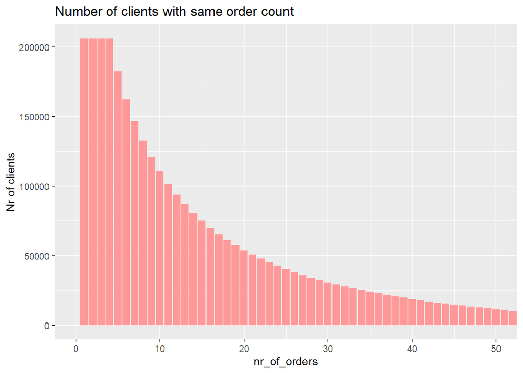

```
## [1] 17.15486
```

```
##   0%  25%  50%  75% 100%
##    1    5   11   23  100
```

Wir wollen auch den Durschnitt von Bestellung von jeden Kunden Berechnen.

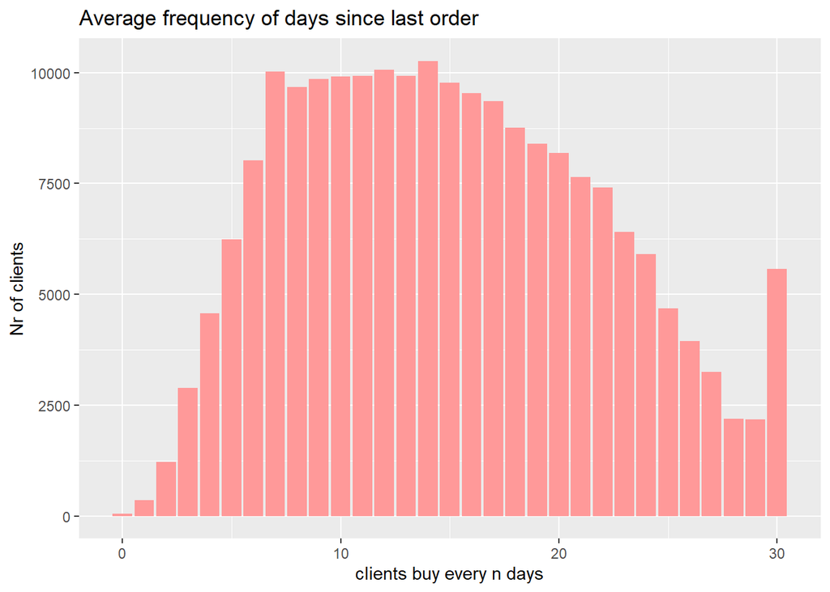

Die totale anzahl an stammkunden ist 103005 von 206209. Dies entsprecht 49.951748% von aller Kunden die je im laden waren

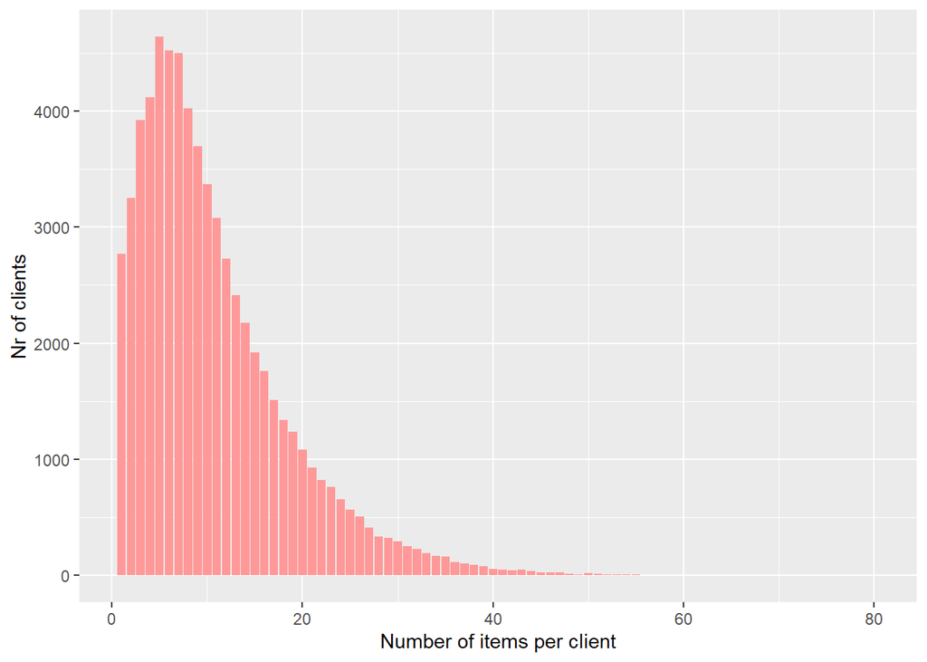

Die Anzahl an transactionen das von Stammkunden geamcht wurden entsprechen 702319 von 1384617. Das entspricht 50.7229797% aller transactionen.